# Lec 21

## Review

**Uncertainty and Statistics**

> “All models are wrong, but some are useful” - George E. P. Box

What is the **primary** goal of statistics?

> Can we achieve this goal without making *any errors*?

We define uncertainty from two central concepts:

For every **population** we can draw information from, there is a sample $X$

The mean of our sample is $\bar{x}$

$\bar{x}$ is **assumed to be normally distributed under two circumstances**

> 1. The distribution of $X$, and thus our **population**, is **NORMAL**
> 2. Our sample size of $X$ is $>30$

> Why does point (1) make sense?

If we draw samples from a population that has **any** distribution

- It’s samples will have **the same** distribution
- A condition where this doesn’t hold is when we **transform** our data somehow
  - i.e., Taking samples from a normally distributed population but transforming the samples to strictly positive, discrete values

> Why does point (2) make sense?

In applied statistics we *check our assumptions*

- Logically the only way to check this assumption would be to take **a lot** of samples
- We’ve done that outside of this class, our assumptions do hold

We **assume** that the distribution of $\bar{x}$ is normal even upon *one observation arising from a sample of* $n>30$

- Empirical **and** mathematical proof are shockingly easy to obtain (and do by hand!)
- I do recommend just seeking out a program to do it for you however

When we sample from a population, and compute a statistic, we’re **always** slightly wrong

- Statistics accepts errors on the single condition that you can **quantify those errors**

**Central Limit Theorem**

Given we have an understanding of the CLT, most of this class should feel *essentially* intuitive

> “…a large, properly draw sample will resemble the population from which it is drawn.” - Charles Wheelan

Think about sampling $40$ defensive linemen from random college football teams

- We can *pretty intuitively* assume that they’re going to be pretty heavy on average
- If we got an average weight of $140$ lbs. we’d be concerned we sampled wrong
- **Not because it’s impossible**
- **But because it’s highly unlikely**

That’s it.

> Confidence Intervals are a way to quantify uncertainty
- Put simply, we’re saying “The true value is $X$, give or take $a$”

We have **two** methods for calculating confidence intervals:

1. $z$-method (given $\sigma$ is known)

$$\bar{x} \pm z_{\alpha/2} \cdot \frac{\sigma}{\sqrt{n}}$$

2. $t$-method (given $\sigma$ is unknown)

$$\bar{x} \pm t_{\alpha/2} \cdot \frac{s}{\sqrt{n}}$$

$t$-method refers directly to the **Students t-distribution**

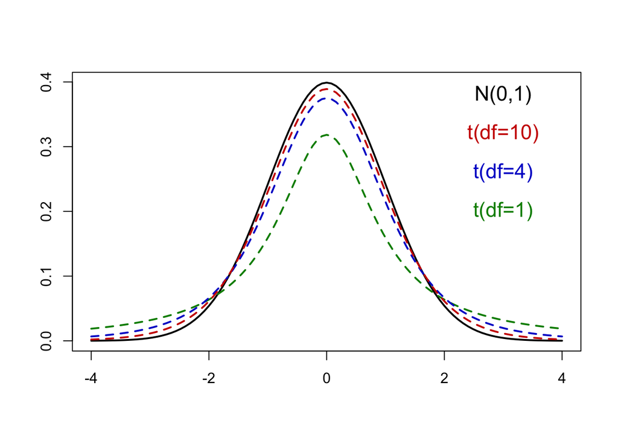

Similar to the standard normal distribution:

- Unimodal
- Symmetric around $0$

Dissimilar from the standard normal distribution:

- *Wider* (or heavier) **tails** than the standard normal
  - Meaning it’s more spread out
- Distinguished by **degrees of freedom** ($df = n - 1$)
  - As $df$ increase the t-distribution converges to a normal distribution

**In practice, we always use the t-method**

*Why?*

**Questions?**

**Goals for today:**

1. Develop a method for dealing with uncertainty in proportional data
2. Introduce the fundamental concepts of Hypothesis testing

## Uncertainty II

### Confidence Intervals for Proportions

**To get a confidence interval we need:**

- Point estimate
- Margin of Error

Our point estimate for $p$ (population proportion):

$$\hat{p}$$

Margin of error is given by:

$$z_{\alpha/2} \sqrt{\frac{\hat{p}(1 - \hat{p})}{n}}$$

We need to **justify** being able to make a confidence interval

- Given the CLT for proportions:

$$n\hat{p} \geq 10 \quad \text{and} \quad n(1 - \hat{p}) \geq 10$$

then the $100(1 - \alpha)\%$ confidence interval for $p$ is:

$$\hat{p} \pm z_{\alpha/2} \sqrt{\frac{\hat{p}(1 - \hat{p})}{n}} \quad \text{(Margin of Error)}$$

Recall that the critical value $z_{\alpha/2}$ comes from the standard normal distribution.

> **Sleep apnea is a disorder in which there are pauses in breathing during sleep.** In a sample of 427 people aged 65 or over, 104 had sleep apnea.

**a.** Find a point estimate for the population proportion of those aged 65 and over who have sleep apnea

$$\hat{p} = \frac{104}{427} \approx 0.244$$

**b.** Compute the margin of error for a 99% confidence level

For 99% confidence, $\alpha/2 = 0.005 \Rightarrow z_{\alpha/2} = 2.576$. The margin of error is:

$$z_{\alpha/2} \times \sqrt{\frac{\hat{p}(1 - \hat{p})}{n}} = 2.576 \times \sqrt{\frac{0.244(1 - 0.244)}{427}} \approx 0.054$$

**c.** Construct a 99% confidence interval for the proportion of those aged 65 or over who have sleep apnea

We construct the 99% confidence interval for $p$ by:

$$\hat{p} \pm \text{Margin of Error} \Rightarrow 0.244 \pm 0.054$$

or $(0.190, 0.298)$

**d.** Does it appear that more than 9% of elderly people have sleep apnea? Yes, all the values in the CI are greater than 0.09.

> Researchers want to estimate the mean amount of sleep per night for students at Upper Midwest University. A sample of 15 students had an average of 6.4 hours per night and a standard deviation of 1.27 hours.

**a.** Should we use the z-method or t-method?

> $t$ method, because $\sigma$ is unknown

**b.** Find a point estimate for the mean amount of sleep per night for UMU students

$$\bar{x} = 6.4$$

**c.** Compute the margin of error for a 90% confidence level

$$\alpha = 1 - 0.90 = 0.10 \Rightarrow \alpha/2 = 0.05$$

With $df = n - 1 = 14$, $t_{\alpha/2} = 1.761$ from the t-table. Compute the margin of error:

$$t_{\alpha/2} \times \frac{s}{\sqrt{n}} = 1.761 \times \frac{1.27}{\sqrt{15}} \approx 0.577$$

**d.** Construct a 90% confidence interval for the mean amount of sleep per night for students at UMU

The 90% CI for the mean amount of sleep is:

$$\bar{x} \pm \text{Margin of Error} \Rightarrow 6.4 \pm 0.577$$

$$\text{or } (5.823, 6.977)$$

**e.** Does the confidence interval contradict a claim that the mean amount of sleep for UMU students is 6 hours? **Explain**

No, because 6 is contained in the confidence interval

> A college admissions officer sampled 107 freshmen and found that 38 scored more than 510 on the math SAT.

**a.** Find a point estimate for the proportion of all entering freshmen at this college who scored more than 510 on the math SAT

$$\hat{p} = \frac{38}{107} \approx 0.355$$

**b.** Compute the margin of error for a 95% confidence level

$$\alpha = 1 - 0.95 = 0.05 \Rightarrow \alpha/2 = 0.025 \Rightarrow z_{\alpha/2} = 1.96$$

Compute the margin of error:

$$z_{\alpha/2} \times \sqrt{\frac{\hat{p}(1 - \hat{p})}{n}} = 1.96 \times \sqrt{\frac{0.355(1 - 0.355)}{107}} \approx 0.091$$

**c.** Construct a 95% confidence interval for the proportion of all entering freshmen who scored more than 510 on the math SAT

$$\hat{p} \pm \text{Margin of Error} \Rightarrow 0.355 \pm 0.091$$

$$\text{or } (0.264, 0.446)$$

We are 95% confident that between 26.4% and 44.6% of the entering freshmen scored more than 510 on the math SAT

### Hypothesis Testing

My philosophy for scientific communication should be apparent by now:

- Why should you care?
- What does this do?
- Why do we use this?

Making claims about statements is **how science works**

- We can convert statements into **parameters**, and make claims about them using **statistics**

We call this: *“Hypothesis Testing”*

- In hypothesis testing, there are two competing statements about population parameters:

$$H_0\equiv \text{null hypothesis} \quad \text{vs} \quad H_1 \equiv \text{alternate hypothesis}$$

Upon forming these statements:

- We use **data** collected from a **sample** to **test** if we
  - Reject $H_0$, thereby supporting $H_1$

A statistical hypothesis is often a statement about **population parameter(s)**

- The null hypothesis, $H_0$, states that the parameter is **equal to** a specific value

$$H_0 : \mu = 35$$

- The alternate hypothesis, $H_1$, states that the value of the parameter **differs** from the value specified by the null hypothesis

$$H_1 : \mu < 35$$

$$H_1 : \mu > 35$$

$$H_1 : \mu \neq 35$$

**There are three types of alternate hypothesis**

- Consider $H_0 : \mu = 35$
1. $H_1 : \mu < 35$ $\Rightarrow$ called **left-tailed** alternate hypothesis
2. $H_1 : \mu > 35$ $\Rightarrow$ called **right-tailed** alternate hypothesis
3. $H_1 : \mu \neq 35$ $\Rightarrow$ called **two-tailed** alternate hypothesis

Left-tailed and right-tailed hypotheses are called **one-tailed** hypotheses

A null hypothesis is generally thought of as a **default state of nature** (e.g. existing knowledge)

An alternate hypothesis, on the other hand, **contradicts** the default state (e.g. new knowledge)

In most cases, whatever **we wish to establish** is placed in the **alternate hypothesis**

After developing $H_0$ and $H_1$, we collect a set of data

- Based on the data, we construct a test statistic to reach one of the following decisions:
  - **Reject** $H_0$
  - **Fail** to reject $H_0$

If we **reject** $H_0$

- We conclude that $H_1$ is **true**

If we **fail to reject** $H_0$

- We conclude that the data **do not provide enough evidence to reject** $H_0$

### Errors in Hypothesis Testing

**We’re making inference about populations from samples**

- We will be a certain amount of wrong
- Depending on how wrong we are, and in what way, we define two types of **errors**

**Type I error**: $H_0$ is true in reality, but we reject $H_0$

**Type II error**: $H_1$ is true in reality, but we do not reject $H_0$

$$\begin{array}{|c|c|c|}
\hline
\text{Decision} & H_0 \ \text{True} & H_0 \ \text{False} \\
\hline
\text{Reject} \ H_0 & \text{Type I error} & \text{Correct decision} \\
\hline
\text{Don’t reject} \ H_0 & \text{Correct decision} & \text{Type II error} \\
\hline
\end{array}$$

The probability of having the Type I error is denoted by $\alpha$

The probability of having the Type II error is denoted by $\beta$

Minimizing both $\alpha$ and $\beta$ is impossible due to a trade-off between $\alpha$ and $\beta$

- If we decrease $\alpha$, then $\beta$ tends to increase

> In general, controlling $\alpha$-level (chance of making Type I error) is more important since Type I error leads to the acceptance of incorrect new knowledge